# JABBA3 user guide

Bayesian state-space surplus production models in RTMB, with FLR inputs and outputs

Henning Winker

31 October 2026

# 1 JABBA3: surplus production models without the JAGS

JABBA3 fits **Bayesian state-space surplus production models**: biomass dynamics driven by a Pella-Tomlinson production function, fishery removals and process error, fitted to one or more abundance indices. It is the successor of JABBA (Just Another Bayesian Biomass Assessment; Winker et al. 2018), rebuilt in RTMB (Kristensen et al. 2016) and with inputs and outputs in FLR (Kell et al. 2007):

- **The same model family as JABBA.** Schaefer, Fox and Pella-Tomlinson production, the JABBA priors (r, K, initial depletion, shape), process error after the catch, additive index variance and catch with error. With the same priors JABBA3 reproduces the JABBA RTMB engine to within $10^{-4}$ in $\log B/B_{MSY}$.
- **Fast.** The log-depletion states are integrated by the Laplace approximation and the fixed effects estimated at the posterior mode; a fit takes well under a second, so retrospectives, hindcasts, sensitivity runs and simulation testing are cheap.
- **Fully Bayesian when needed.** The same objective can be sampled with NUTS (tmbstan; Monnahan and Kristensen 2018) for final runs and credible intervals.
- **Process error from BioProcDyn.** Production lag at the age at maturity, AR(1) process deviations, depletion-dependent process error and a life-history (FishLife) prior on its scale.
- **Diagnostics.** One-step-ahead (OSA) residuals by particle filter, runs tests, the SPiCT residual tests, retrospective analysis (Mohn’s rho) and hindcast cross-validation (MASE).
- **FLR inside.** Catch as `FLQuant`, indices as `FLIndices`; status, reference points and parameters out as `FLQuants` and `FLPar`.
- **Converters.** Classic JABBA data frames, JABBA `build_jabba()` objects and SPiCT input lists convert to JABBA3 inputs.

> **JABBA and JABBA3.** Since version 2.x, JABBA itself has an RTMB engine in addition to JAGS, which few users are aware of. JABBA3 is the standalone RTMB successor. In this guide “JABBA” means the original package (JAGS, with its RTMB engine) and “JABBA3” the new one.

How JABBA options map to JABBA3:

| JABBA | JABBA3 |
| --- | --- |
| `build_jabba(catch, cpue, se, ...)` | `jb3_data()` + `jb3_priors()` + `jb3_model()`, or `jbinput2jabba3(jbinput)` |
| `fit_jabba()` (JAGS) | `jabba3(engine = "rtmb")` (mode) or `jabba3(engine = "nuts")` |
| `r.prior`, `K.prior`, `psi.prior` | `jb3_priors(r = , K = , bkinit = )`, each `c(median, log.sd, on)` |
| `sigma.proc.prior` (inverse-gamma) | `jb3_priors(sdb = "fishlife")` (lognormal, life-history centre) |
| `model.type`, `BmsyK` | `jb3_model(shape = , BmsyK = )` |
| `sigma.est`, `fixed.obsE` | estimated `sdi` + input SEs (`obs.error = "additive"`) |
| `add.catch.CV` | `jb3_model(catch.error = TRUE, sdc = 0.1)` |
| `jbplot_*()` | `jbplot_*()` (ggplot2) |

## 1.1 About this guide

**Part I** (sections 3-9) goes through an assessment from the data to stock status: data, priors, model options, fitting, convergence and residual diagnostics, with **checks** at each step (what to look at, what is a red flag, what to do about it). **Part II** (sections 10-15) covers NUTS, the BioProcDyn process-error workflows, projections, FLR outputs, converters from JABBA and SPiCT, and the model equations. Section 16 summarises the checks and the functions. The examples use the built-in ICCAT data (`data(iccat)`): Atlantic bigeye tuna, white marlin, South Atlantic swordfish and blue marlin.

> This is a first draft (prototype, 30 October 2026). Interfaces may still change.

# 2 Installation

JABBA3 depends on `RTMB` and `ggplot2`. NUTS needs `tmbstan` (and `rstan`); FLR inputs and outputs need `FLCore` (and `ggplotFL` for plotting); `patchwork` is used for multi-panel diagnostics. The converters from JABBA need the `JABBA` package.

```r
install.packages(c("RTMB", "ggplot2", "Matrix", "tmbstan", "rstan", "patchwork"))
install.packages(c("FLCore", "ggplotFL"),
                 repos = c("https://flr.r-universe.dev", "https://cloud.r-project.org"))
remotes::install_github("Henning-Winker/JABBA3@converters")
```

```r
library(JABBA3)
packageVersion("JABBA3")
```

```
#> [1] '3.0.0.9000'
```

```r
jabba3_info()
```

# 3 Quick start: your first fit

Atlantic bigeye tuna is the standard example of this guide: catch from 1950 and two Japanese longline CPUE indices with log-scale standard errors, in the JABBA data-frame format. Atlantic blue marlin, a more complex assessment with ten indices, introduces the rebuilding protocol (chapter *The rebuilding protocol*).

```r
data(iccat)
names(iccat)
```

```
#> [1] "bet"  "whm"  "swos" "bum"
```

```r
bet <- iccat$bet
head(bet$catch, 3)
```

```
#>   year Total
#> 1 1950   808
#> 2 1951  1651
#> 3 1952  2018
```

```r
head(bet$cpue[bet$cpue$year >= 1959, ], 3)
```

```
#>    year JR2_early JR2_late
#> 10 1959 0.8423903       NA
#> 11 1960 0.9248946       NA
#> 12 1961 1.1712004       NA
```

Three steps: data, priors, fit.

```r
d   <- jb3_data(bet$catch, bet$cpue, bet$se, stock = "bet")
pr  <- jb3_priors(d, r = c(0.2, 0.5))
fit <- jabba3(d, pr, jb3_model(shape = "fox"), ndraws = 1000)
fit
```

```
#> JABBA3 fit: bet ( bet )  engine: rtmb  + 1000 mvn draws
#>   model: fox
#>   convergence: ok (max gradient 4.4e-12, Newton decrement 3.0e-25)
#>   estimates (mode, 95% CI):
#>             est      lci      uci
#> K      1.17e+06 6.89e+05 2.00e+06
#> r      1.93e-01 1.07e-01 3.49e-01
#> bkinit 8.89e-01 5.50e-01 1.43e+00
#> sdb    9.45e-02 6.31e-02 1.42e-01
#> q1     9.07e-07 4.87e-07 1.69e-06
#> q2     1.71e-06 9.20e-07 3.16e-06
#> sdi1   5.01e-02 1.65e-02 1.53e-01
#> sdi2   4.40e-02 1.66e-02 1.16e-01
#> m      1.00e+00       NA       NA
#> Bmsy   4.32e+05 2.53e+05 7.37e+05
#> Fmsy   1.93e-01 1.07e-01 3.48e-01
#> MSY    8.33e+04 7.01e+04 9.91e+04
#>   status 2017: B/Bmsy 0.80 (0.54-1.18), F/Fmsy 1.16 (0.72-1.87)
```

## 3.1 Quick output: `plot(fit)`

`plot(fit)` (or `jabbaplot3(fit)`) is the one-page summary of a fit, as SPiCT’s `plot()`:

- **top row:** biomass (with the observed indices scaled by $q$ as points), $F$ and catch, with MSY reference points and $B_{thr} = 0.5 B_{MSY}$ and $B_{lim} = 0.3 B_{MSY}$;
- **middle row:** $B/B_{MSY}$ (again with the scaled indices), $F/F_{MSY}$ and the Kobe plot with the uncertainty of the terminal year;
- **bottom row:** the process deviations, the realised surplus production $B_{t+1} - B_t + C_t$ against biomass with the production curve, and the production phase plot: catches against biomass on the Kobe colours, with the MSY band.

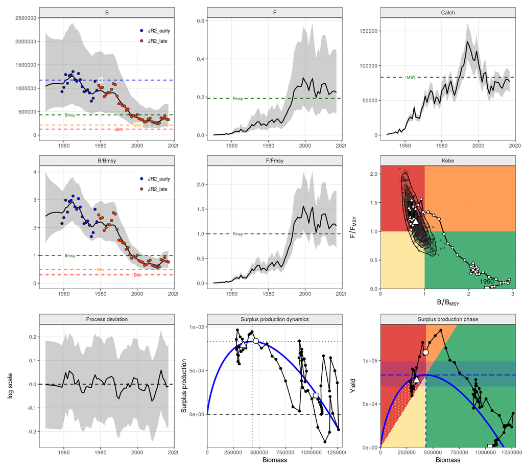

```r
plot(fit)
```

`plot(fit, "simple")` gives a 2 x 2 version ($B/B_{MSY}$, $F/F_{MSY}$, catch, Kobe; as SPiCT’s `plot2()`), and `panels =` picks any set of panels, e.g. `plot(fit, panels = c("B/Bmsy", "F/Fmsy", "fits", "residuals"))`.

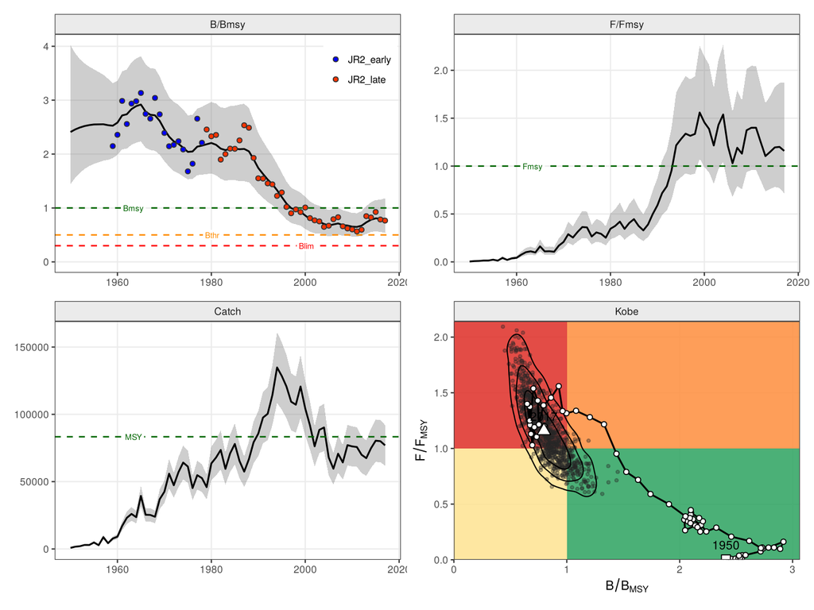

```r
plot(fit, "simple")
```

## 3.2 Individual plots

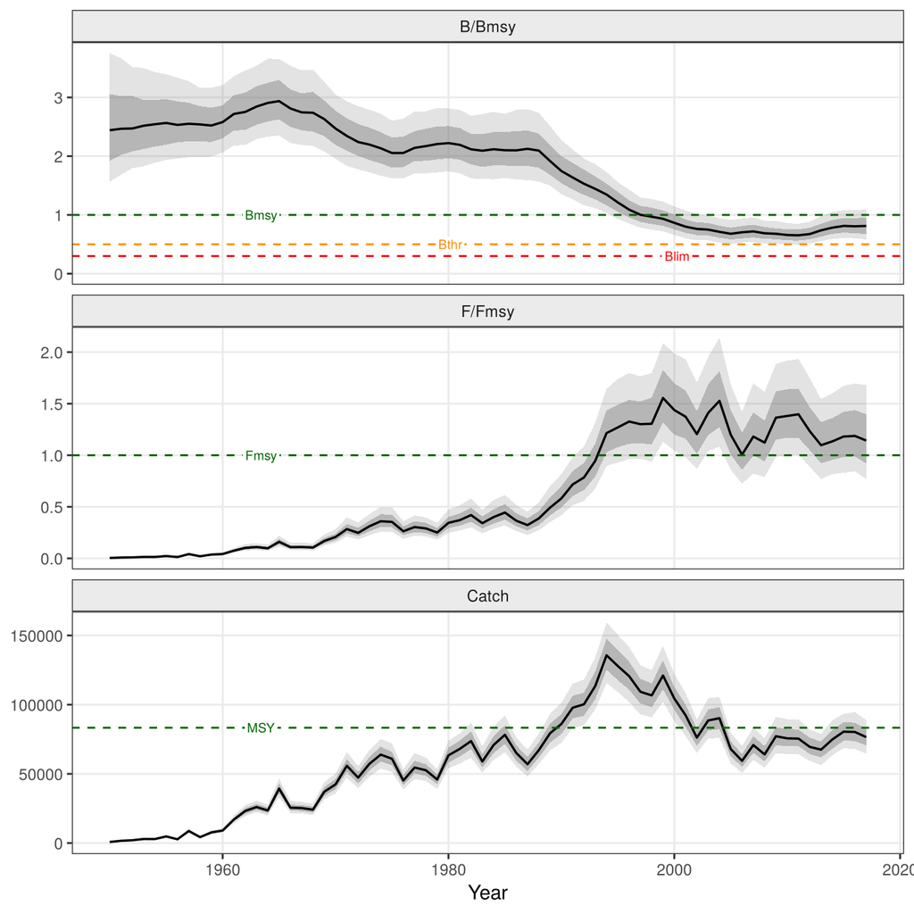

```r
jbplot_advice(fit)
```

The advice plot follows FLRef’s `plotAdvice()` and JAGG: the median with nested 90% and 60% bands and the MSY reference points as labelled lines.

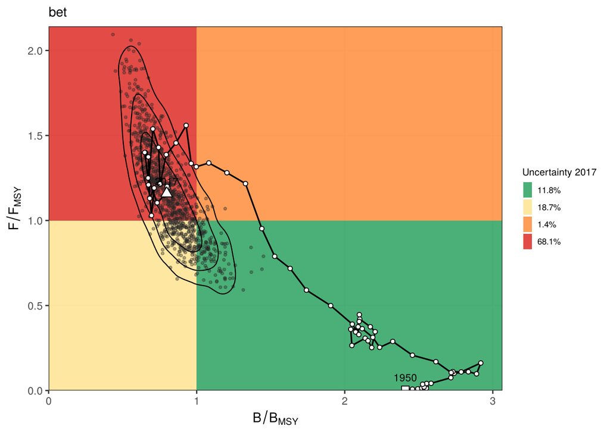

```r
jbplot_kobe(fit)
```

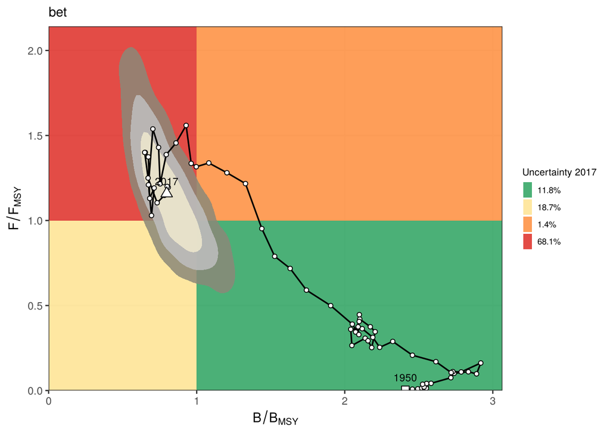

```r
jbplot_kobe(fit, style = "contours")   # filled 50/80/95% regions, as jbplot_biplot(); contours = FALSE: points only
```

`jbplot_all(fit, dir)` writes all standard plots of a fit to PNG files.

# 4 Data

## 4.1 Data frames (JABBA format)

`jb3_data()` takes the JABBA data frames directly: `catch` (`year, catch[, fleet 2, ...]`), `cpue` (`year, index1, index2, ...`, `NA` for missing years) and optionally `se` (log-scale standard errors, same columns as `cpue`). Catches by fleet are summed for the fit and kept in `catch.fleets`.

```r
d <- jb3_data(bet$catch, bet$cpue, bet$se, stock = "bet")
d$years
```

```
#>  [1] 1950 1951 1952 1953 1954 1955 1956 1957 1958 1959 1960 1961 1962 1963 1964
#> [16] 1965 1966 1967 1968 1969 1970 1971 1972 1973 1974 1975 1976 1977 1978 1979
#> [31] 1980 1981 1982 1983 1984 1985 1986 1987 1988 1989 1990 1991 1992 1993 1994
#> [46] 1995 1996 1997 1998 1999 2000 2001 2002 2003 2004 2005 2006 2007 2008 2009
#> [61] 2010 2011 2012 2013 2014 2015 2016 2017
```

```r
str(d$I)
```

```
#>  num [1:68, 1:2] NA NA NA NA NA ...
#>  - attr(*, "dimnames")=List of 2
#>   ..$ : chr [1:68] "1950" "1951" "1952" "1953" ...
#>   ..$ : chr [1:2] "JR2_early" "JR2_late"
```

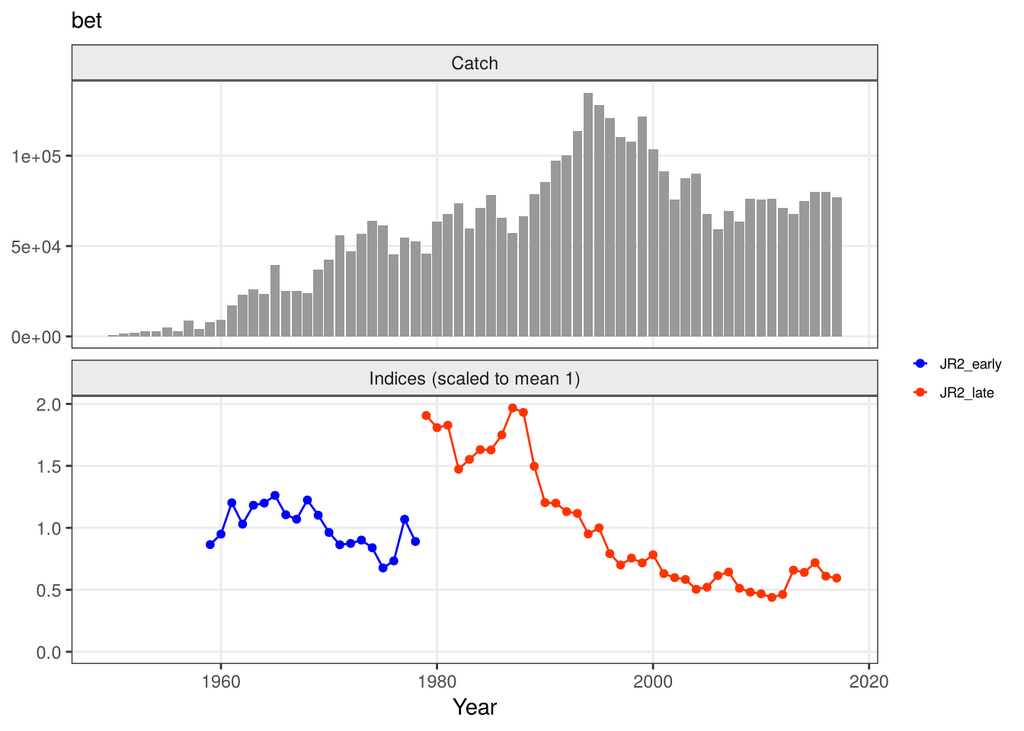

```r
jbplot_data(d)
```

`jbplot_indices()` shows each index scaled to its mean with the 95% interval from the input standard errors, as JABBA’s plot of the same name:

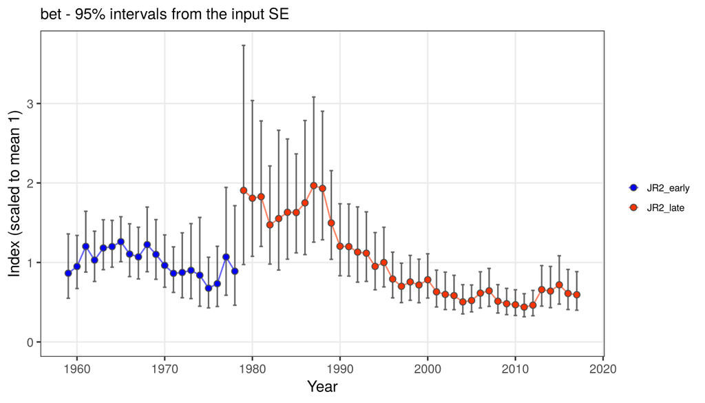

```r
jbplot_indices(d)
```

## 4.2 FLR objects

The native input is catch as an `FLQuant` (or `FLQuants` by fleet) and indices as `FLIndices` of `FLIndexBiomass`, with the log-scale standard errors in `index.var`. `jbdat2flr()` converts the JABBA data frames, and `flr2jbdat()` converts back:

```r
library(FLCore)
x <- jbdat2flr(bet$catch, bet$cpue, bet$se)
names(x)                    # auxiliary is NULL when not given
```

```
#> [1] "catch"     "indices"   "auxiliary"
```

```r
x$catch[, ac(2013:2017)]
```

```
#> An object of class "FLQuant"
#> , , unit = unique, season = all, area = unique
#>
#>      year
#> age   2013  2014  2015  2016  2017
#>   all 67849 75029 80172 79909 76982
#>
#> units:  t
```

```r
names(x$indices)
```

```
#> [1] "JR2_early" "JR2_late"
```

```r
index.var(x$indices[[2]])[, ac(2013:2017)]
```

```
#> An object of class "FLQuant"
#> , , unit = unique, season = all, area = unique
#>
#>      year
#> age   2013  2014  2015  2016  2017
#>   all 0.193 0.201 0.210 0.205 0.203
#>
#> units:  NA
```

```r
d.flr <- jb3_data(x$catch, x$indices, stock = "bet")
all.equal(d.flr$I, d$I, check.attributes = FALSE)
```

```
#> [1] TRUE
```

All functions that take the data work the same way with FLR input; `jbplot_data()` also takes the FLR objects directly:

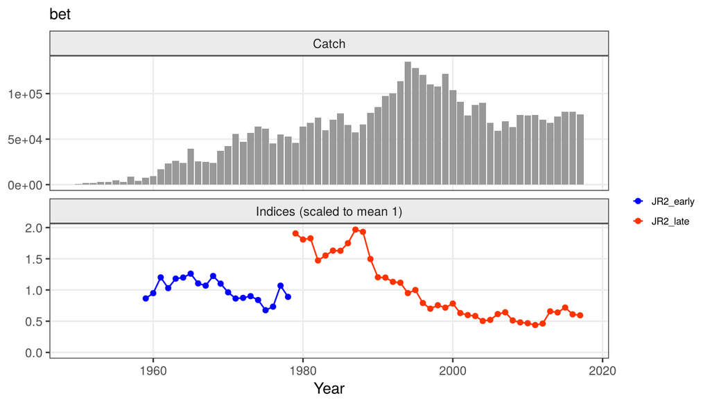

```r
jbplot_data(x$catch, x$indices, stock = "bet")
```

Several catch columns give `FLQuants` (one per fleet) unless `fleets = FALSE`. `jbcatch2flq()` and `jbidx2FLIndices()` convert the catch and the indices separately.

## 4.3 Check 1: the data

`jbplot_data()` shows the catch and the indices. Look for:

| What | Red flag | Action |
| --- | --- | --- |
| contrast | indices flat while catch changes, or the reverse | r and K are confounded; tighter r prior, or use status priors |
| index overlap | indices in conflict where they overlap | separate `sdi`; drop or down-weight one index; sensitivity runs |
| standard errors | very small SEs (< 0.05) | the estimated `sdi` adds variance, but check where the SEs come from |
| catch | gaps, early catch reconstructed | `catch.error = TRUE` (default); start later with `bkinit` prior |

# 5 Data exploration: index trends and joint indices

Before fitting a production model it pays to look at the abundance indices on their own: do they tell the same story, how do they scale against each other, and do some of them conflict? JABBA3 includes the trend models of JARA, refitted in RTMB, for this: a state-space random walk with drift on log abundance, observed through one or several indices. For index $i$ in year $t$:

$$x_t = x_{t-1} + r + \eta_t,\quad \eta_t \sim N(0, \sigma_p^2);\qquad
\log I_{i,t} = \log q_i + x_t + \varepsilon_{i,t},\quad
\varepsilon_{i,t} \sim N(0, se_{i,t}^2 + \sigma_{fix}^2 + \sigma_i^2)$$

The common state $x_t$ is the joint trend; each index has its own catchability $q_i$, relative to the first (reference) index with $q_1 = 1$, and its own additional observation SD $\sigma_i$ (`variance.weighting = "model"`; `"equal"` estimates one common value, `"fixed"` none; `fixed.obsE` is $\sigma_{fix}$). The joint index follows the hierarchical analysis of multiple noisy abundance indices of Conn (2010), widely used in US (SEDAR) assessments: JARA’s random-walk form gives practically the same joint index as Conn’s independent year effects (`state = "iid"`).

The fits carry the same diagnostics as a `jabba3()` fit (fits, runs tests, joint residuals, posterior predictive checks), with one-step-ahead (OSA) residuals by default and `type = "ordinary"` for the log residuals used in JARA reports.

**Log-scale standard errors.** All models use observation errors on the log scale. From a design-based SD of the untransformed index, use $CV = sd/mean$ and $\sigma = \sqrt{\log(CV^2 + 1)}$ (close to the CV for CV < 0.4); from a 95% interval, $\sigma = (\log(uci) - \log(lci))/(2 \times 1.96)$.

## 5.1 Concept: hierarchical analysis of multiple indices

The joint-index models rest on the hierarchical framework of Conn (2010). Each index $i$ is taken to measure the same relative abundance $n_t$, but through its own catchability $c_i = \log q_i$, with two kinds of error: process error $\sigma_{p,i}$, from year-to-year variation in catchability or in the spatial distribution of the stock relative to the fishery or survey, and sampling error $\sigma_{s,it}$, known from the input CV of each value:

$$\log U_{it} \sim N\left(n_t + c_i,\; \sigma_{p,i}^2 + \sigma_{s,it}^2\right)$$

Only differences between the $c_i$ are identifiable, so one constraint is needed: a reference index with $c_1 = 0$ ($q_1 = 1$; JABBA3) or an anchor on the mean of the $c_i$ or $n_t$. Conn treats the $n_t$ as independent year effects; JABBA3 (following JARA) places a random walk with drift on $n_t$ (`state = "rw"`), which carries the trend through years with few or no observations, and fits Conn’s form with `state = "iid"`. The estimated index-specific $\sigma_{p,i}$ correspond to JABBA3’s additional observation SD $\sigma_i$ (`variance.weighting = "model"`). The outputs follow directly: each $q_i$ is the scale of index $i$ *relative to the reference index*, not an absolute catchability; the joint index is the estimated $n_t$ with its uncertainty; and residual patterns that persist for one index against the common trend point to conflicts between indices rather than to noise.

## 5.2 Aligning indices: bigeye tuna

The two Japanese longline CPUE series of bigeye cover consecutive periods (1959-1978 and 1979-2017) and do not overlap. A relative trend model aligns them on one consistent trend, each index scaled by its catchability:

```r
tr.bet <- jb3_trend(bet$cpue, bet$se, run = "bigeye")
tr.bet
```

```
#> JABBA3 trend fit (relative): bigeye
#>   indices: JR2_early, JR2_late | years 1959 - 2017
#>   convergence: ok (max gradient 2.3e-12)
#>   process SD = 0.068
#>   drift r:
#>            trend
#> 1959-2017 -0.027
#>      index    q    sdi
#>  JR2_early 1.00 0.0483
#>   JR2_late 2.36 0.0413
```

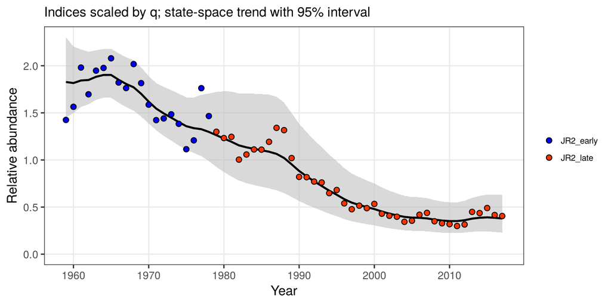

```r
jbplot_trend(tr.bet)
```

`jb3_qtable()` gives the catchability of each index relative to the reference index (the first one, q = 1 by definition) with its 95% interval, and `jbplot_q()` its distribution, with the reference as a vertical line at 1:

```r
knitr::kable(jb3_qtable(tr.bet, digits = 3), row.names = FALSE)
```

| index | q | lci | uci | log.se | n | years | reference |
| --- | --- | --- | --- | --- | --- | --- | --- |
| JR2_early | 1.00 | 1.00 | 1.00 | NA | 20 | 1959-1978 | TRUE |
| JR2_late | 2.36 | 1.55 | 3.59 | 0.215 | 39 | 1979-2017 | FALSE |

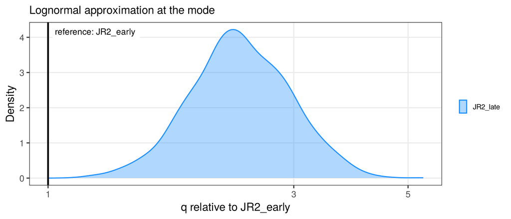

```r
jbplot_q(tr.bet)
```

The late series has a catchability about 2.4 times that of the early series. Because the series do not overlap, the scaling rests on the continuity of the trend across 1978/79, and the interval is correspondingly wide. In the production model, the two series keep their own q; the trend model shows how much the data alone say about their relative scale.

## 5.3 Why catchabilities differ: changes in vessel, gear and method

Differences in q between series are rarely a nuisance parameter only. In fishery-independent surveys, abrupt changes in catchability follow changes of research vessel or trawl gear. A comparison of design-based swept-area estimates and geostatistical delta-GLMM indices (Thorson et al. 2015) for eight species of a demersal trawl survey (Winker et al. 2017) found clear vessel effects for several species, seen as abrupt steps in the index at the change of research vessel, and a gear effect (lower catchability with the new gear) for one species. Both estimators showed the same steps, so the change was in q, not in the estimator. Such a change should be modelled as a change in q, not read as a change in abundance: split the index at the known change and let the trend model (or the production model) estimate a q for each period.

`jb3_splitindex()` does the split. A hypothetical example: a survey index whose new vessel, from 2009, catches 40% less than the old one (q ratio 0.6).

```r
a  <- jara_examples$areas
s  <- a$idx[c("year", "area3")]; se <- a$idx.se[c("year", "area3")]
new.v <- 0.6*s$area3                          # what the new vessel would catch
obs <- s; obs$area3[s$year >= 2009] <- new.v[s$year >= 2009]
# (a) no overlap: the old vessel stops in 2008
x0 <- jb3_splitindex(obs, se, "area3", at = 2009, labels = c("vessel.old", "vessel.new"))
# (b) three calibration years (2009-2011) fished with both vessels
obs1 <- obs; cy <- 2009:2011; obs1$area3[s$year %in% cy] <- s$area3[s$year %in% cy]
x1 <- jb3_splitindex(obs1, se, "area3", at = 2009, overlap = cy, new = new.v[s$year %in% cy],
                     labels = c("vessel.old", "vessel.new"))
q.split <- rbind(cbind(design = "no overlap", jb3_qtable(jb3_trend(x0$I, x0$se), digits = 3)[2, ]),
                 cbind(design = "3 calibration years", jb3_qtable(jb3_trend(x1$I, x1$se), digits = 3)[2, ]))
knitr::kable(q.split[, c("design", "index", "q", "lci", "uci")], row.names = FALSE,
             caption = "q of the new vessel relative to the old (true value 0.6)")
```

q of the new vessel relative to the old (true value 0.6)

| design | index | q | lci | uci |
| --- | --- | --- | --- | --- |
| no overlap | vessel.new | 1.060 | 0.544 | 2.080 |
| 3 calibration years | vessel.new | 0.644 | 0.458 | 0.906 |

Without overlap the trend model cannot tell a lower q from a decline in the stock: the estimated ratio is close to 1 with a wide interval, and the step appears as a decline in the common trend. Three calibration years recover the ratio (about 0.64, interval excluding 1). The same holds for the bigeye longline series above, whose relative q rests on the continuity of the trend alone. Other indices help to identify a change in q only if they follow the same trend; indices from areas with different trends (chapter *Other data features*) do not.

## 5.4 Observation and process noise of indices

Survey indices from a design-based swept-area estimator assume that density is homogeneous within each stratum. For patchy species, or species found in only part of the survey area, the catch rates of randomly placed stations then vary widely, and the index is imprecise and shows spikes that are implausible for the population (Winker et al. 2017). Model-based standardisation, such as the geostatistical delta-GLMM, accounts for the spatial correlation of density and reduces both the observation error and this year-to-year “process noise”. In the survey comparison of Winker et al. (2017), the geostatistical indices had lower observation-error CVs for all eight species (e.g. 0.12 against 0.18 for one hake species, 0.27 against 0.39 for a patchy by-catch species), and lower process-error CVs (Francis 2011), with the largest reductions for the patchy by-catch species (0.49 to 0.35) and for the most commonly caught hake (0.53 to 0.46). The mean trends of the two estimators agreed.

For an assessment, process noise in an index is variation in catchability or availability that the sampling error does not capture. It is what the additional SD of each index against the common trend, $\sigma_{p,i}$ (Conn 2010), estimates. `jb3_noise()` sets three measures side by side: the mean input CV, the loess process CV of Francis (2011) from a smoother through the log index, and, for a trend fit, $\sigma_{p,i}$ and the RMSE against the common trend.

## 5.5 Index conflicts and a joint index: blue marlin

The 2018 blue marlin assessment used ten CPUE series of different fleets and periods. Before combining them, check whether they agree. A first look: correlations of the log indices over the years each pair shares (`jbplot_indexcor()`; blank where fewer than five years overlap):

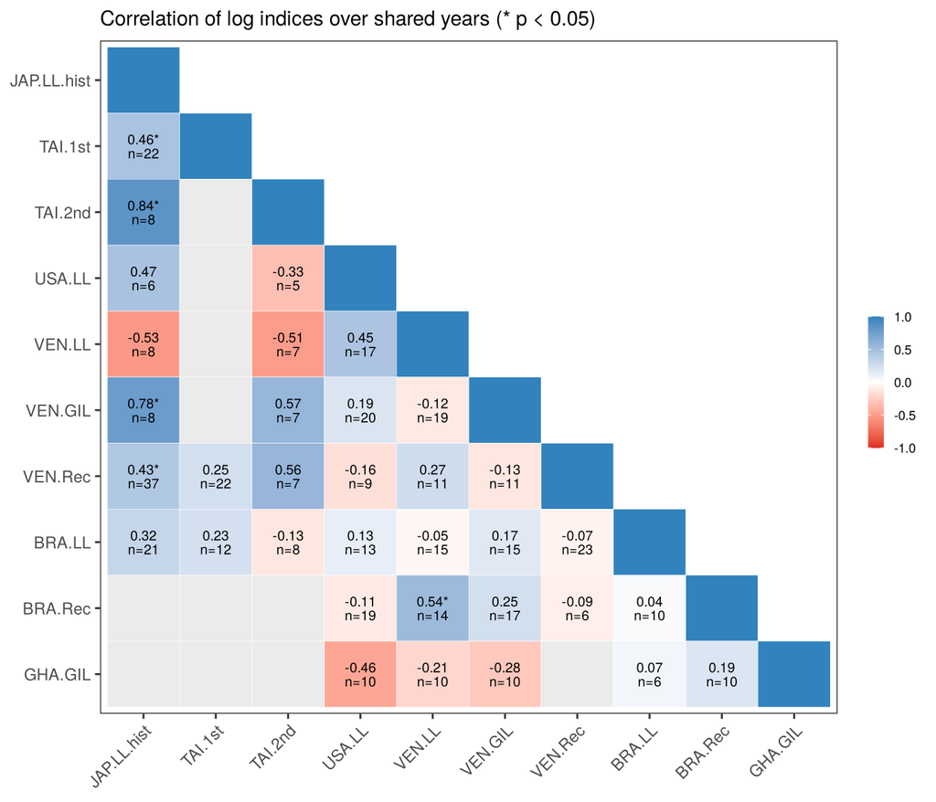

```r
bum <- iccat$bum
tr.bum <- jb3_trend(bum$cpue, bum$se, run = "blue marlin")
jbplot_indexcor(tr.bum)
```

Of the 34 pairs with at least five shared years, 14 are negatively correlated, though none significantly, while five positive correlations are significant. Correlations over few shared years are a weak test, so the trend model’s residuals are the main check. The joint residual plot shows the residuals of all indices against the common trend, with their RMSE and a loess smoother; conflicting indices show opposite residual patterns in the same years:

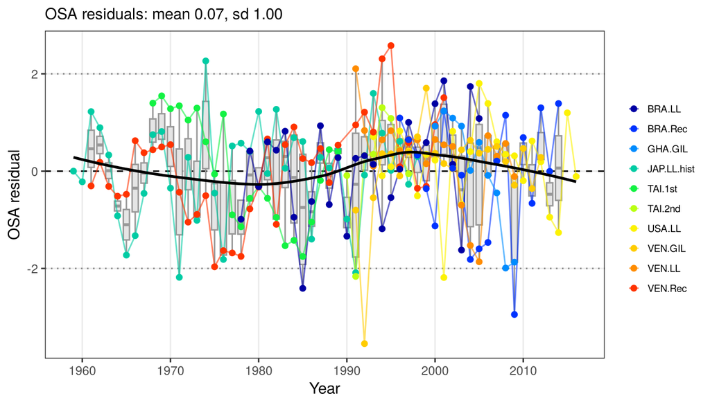

```r
jbplot_residuals(tr.bum)
```

Runs tests by index (OSA residuals) and posterior predictive checks:

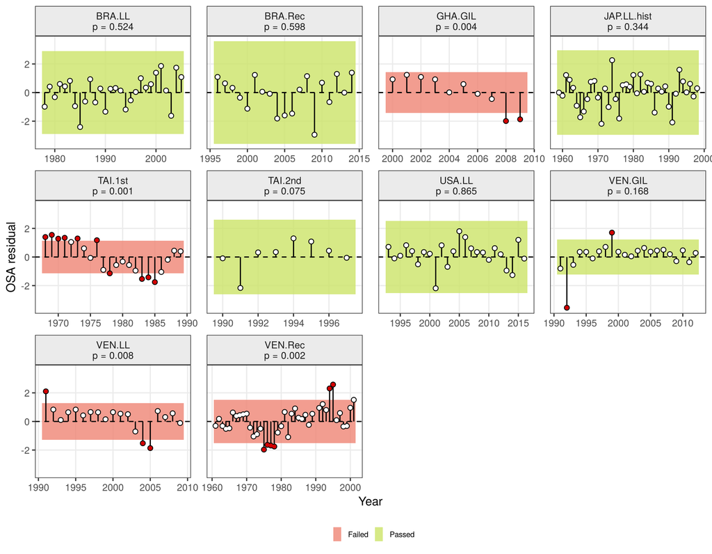

```r
p.runs <- jbplot_runs(tr.bum)
p.runs
```

```r
attr(p.runs, "runs")[, c("index", "p.runs", "test")]
```

```
#>                   index p.runs   test
#> JAP.LL.hist JAP.LL.hist  0.344 Passed
#> TAI.1st         TAI.1st  0.001 Failed
#> TAI.2nd         TAI.2nd  0.075 Passed
#> USA.LL           USA.LL  0.865 Passed
#> VEN.LL           VEN.LL  0.008 Failed
#> VEN.GIL         VEN.GIL  0.168 Passed
#> VEN.Rec         VEN.Rec  0.002 Failed
#> BRA.LL           BRA.LL  0.524 Passed
#> BRA.Rec         BRA.Rec  0.598 Passed
#> GHA.GIL         GHA.GIL  0.004 Failed
```

```r
p.ppc <- jbplot_ppc(tr.bum)
attr(p.ppc, "ppc")
```

```
#>                   index Bayesian.p nobs
#> JAP.LL.hist JAP.LL.hist      0.530   40
#> TAI.1st         TAI.1st      0.369   22
#> TAI.2nd         TAI.2nd      0.453    8
#> USA.LL           USA.LL      0.595   24
#> VEN.LL           VEN.LL      0.777   19
#> VEN.GIL         VEN.GIL      0.535   22
#> VEN.Rec         VEN.Rec      0.473   40
#> BRA.LL           BRA.LL      0.412   28
#> BRA.Rec         BRA.Rec      0.172   19
#> GHA.GIL         GHA.GIL      0.278   10
```

Four indices fail the runs test against the common trend (`TAI.1st`, `VEN.LL`, `VEN.Rec`, `GHA.GIL`); three of them have among the largest additional observation SDs (`sdi` in the print), i.e. the model already down-weights them. The posterior predictive p-values are all between 0.17 and 0.78, so no index is grossly inconsistent with the joint model. The relative catchabilities follow below. First, the noise of each index:

```r
knitr::kable(jb3_noise(tr.bum), row.names = FALSE)
```

| index | n | years | obs.cv | loess.cv | sd.extra | sd.total | rmse |
| --- | --- | --- | --- | --- | --- | --- | --- |
| JAP.LL.hist | 40 | 1959-1998 | 0.125 | 0.236 | 0.065 | 0.141 | 0.158 |
| TAI.1st | 22 | 1968-1989 | 0.103 | 0.314 | 0.645 | 0.654 | 0.691 |
| TAI.2nd | 8 | 1990-1997 | 0.102 | 0.124 | 0.127 | 0.163 | 0.140 |
| USA.LL | 24 | 1993-2016 | 0.183 | 0.223 | 0.174 | 0.253 | 0.203 |
| VEN.LL | 19 | 1991-2009 | 0.569 | 0.301 | 0.126 | 0.583 | 0.463 |
| VEN.GIL | 22 | 1991-2012 | 0.389 | 0.468 | 0.584 | 0.702 | 0.586 |
| VEN.Rec | 40 | 1961-2001 | 0.394 | 0.595 | 0.629 | 0.742 | 0.716 |
| BRA.LL | 28 | 1978-2005 | 0.229 | 0.446 | 0.395 | 0.456 | 0.450 |
| BRA.Rec | 19 | 1996-2014 | 0.448 | 0.631 | 0.104 | 0.460 | 0.700 |
| GHA.GIL | 10 | 2000-2009 | 0.262 | 0.335 | 0.953 | 0.988 | 1.103 |

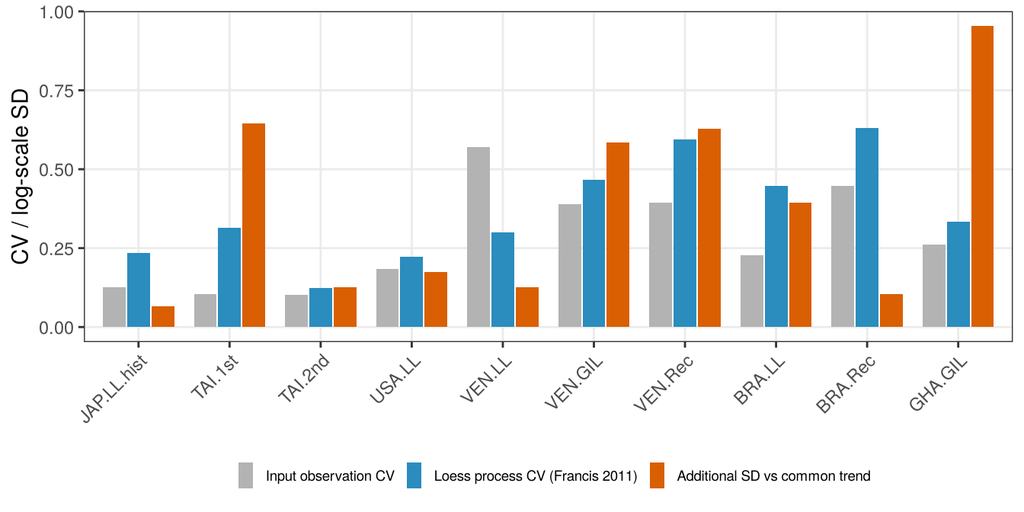

```r
jbplot_noise(tr.bum)
```

Three of the four series flagged by the runs tests (`TAI.1st`, `VEN.Rec`, `GHA.GIL`) carry additional SDs of 0.6-1.0 against the common trend, well beyond their input CVs (0.10-0.39). For `VEN.Rec` the loess CV is similarly high (0.60): the series is noisy around its own trend. For `TAI.1st` and `GHA.GIL` the additional SD is two to three times the loess CV: the series are fairly smooth but follow a different trend, which is a conflict with the other indices rather than noise. `VEN.LL`, the fourth, is the reverse case: its input CV (0.57) already exceeds its loess CV and RMSE, so its runs-test failure reflects a residual pattern, not unaccounted noise. The relative catchabilities:

```r
knitr::kable(jb3_qtable(tr.bum, digits = 3), row.names = FALSE)
```

| index | q | lci | uci | log.se | n | years | reference |
| --- | --- | --- | --- | --- | --- | --- | --- |
| JAP.LL.hist | 1.000 | 1.000 | 1.00 | NA | 40 | 1959-1998 | TRUE |
| TAI.1st | 0.993 | 0.752 | 1.31 | 0.1420 | 22 | 1968-1989 | FALSE |
| TAI.2nd | 2.060 | 1.800 | 2.35 | 0.0672 | 8 | 1990-1997 | FALSE |
| USA.LL | 2.210 | 1.840 | 2.65 | 0.0936 | 24 | 1993-2016 | FALSE |
| VEN.LL | 1.630 | 1.240 | 2.15 | 0.1400 | 19 | 1991-2009 | FALSE |
| VEN.GIL | 1.850 | 1.330 | 2.56 | 0.1660 | 22 | 1991-2012 | FALSE |
| VEN.Rec | 0.969 | 0.766 | 1.23 | 0.1200 | 40 | 1961-2001 | FALSE |
| BRA.LL | 1.640 | 1.370 | 1.97 | 0.0934 | 28 | 1978-2005 | FALSE |
| BRA.Rec | 2.220 | 1.740 | 2.82 | 0.1230 | 19 | 1996-2014 | FALSE |
| GHA.GIL | 1.520 | 0.794 | 2.92 | 0.3320 | 10 | 2000-2009 | FALSE |

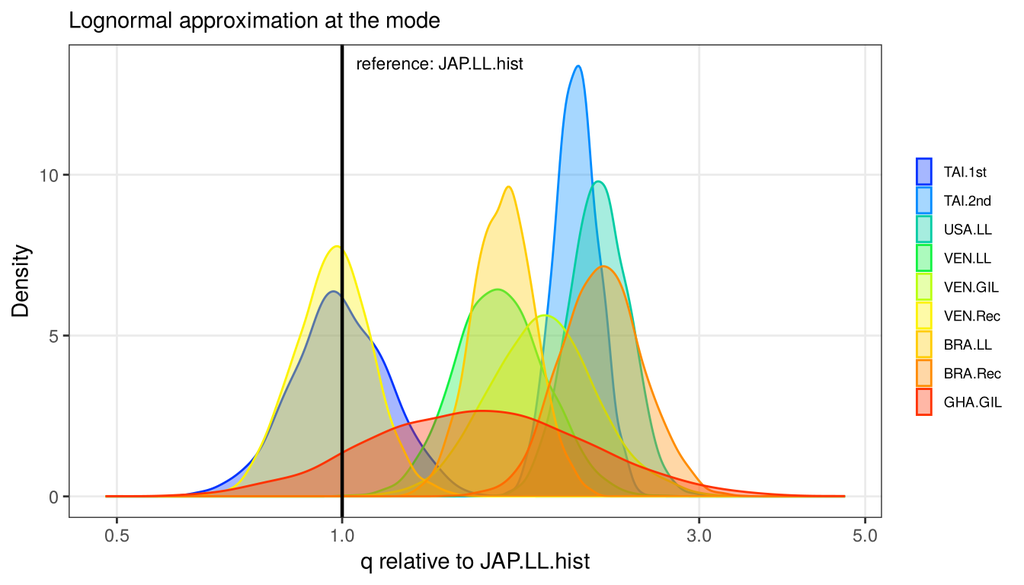

```r
jbplot_q(tr.bum)
```

The joint index combines the ten series into one, the precision-weighted mean of the q-scaled indices by year with its log-scale SE:

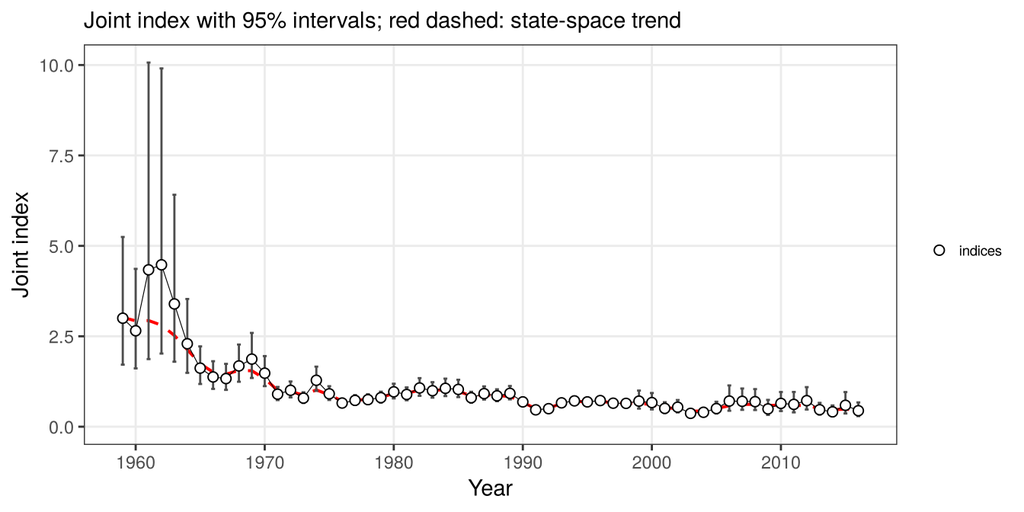

```r
bum.joint <- jb3_jointindex(tr.bum, name = "joint")
jbplot_jointindex(tr.bum)
```

```r
knitr::kable(head(bum.joint, 6), digits = 3, row.names = FALSE)
```

| year | trend | index | log.se | lci | uci | source |
| --- | --- | --- | --- | --- | --- | --- |
| 1959 | 3.020 | 2.999 | 0.285 | 1.715 | 5.246 | indices |
| 1960 | 2.927 | 2.652 | 0.254 | 1.612 | 4.364 | indices |
| 1961 | 2.934 | 4.338 | 0.430 | 1.869 | 10.068 | indices |
| 1962 | 2.807 | 4.476 | 0.405 | 2.022 | 9.907 | indices |
| 1963 | 2.522 | 3.394 | 0.325 | 1.796 | 6.413 | indices |
| 1964 | 2.130 | 2.293 | 0.220 | 1.489 | 3.532 | indices |

`bum.joint` is used in the blue marlin case study (chapter *The rebuilding protocol*) to compare an assessment on the joint index with one on the ten separate indices.

**Random walk (JARA) or independent year effects (Conn 2010).** The blue marlin indices overlap enough for Conn’s form, which treats the years as independent effects rather than a random walk; the two joint indices are practically the same:

```r
jc <- jb3_jointindex(jb3_trend(bum$cpue, bum$se, state = "iid", run = "Conn (iid)"))
ok <- is.finite(bum.joint$index) & is.finite(jc$index)
cmp <- data.frame(year = bum.joint$year[ok], rw = bum.joint$index[ok]/mean(bum.joint$index[ok]),
                  iid = jc$index[ok]/mean(jc$index[ok]))
round(cor(log(cmp$rw), log(cmp$iid)), 3)
```

```
#> [1] 0.994
```

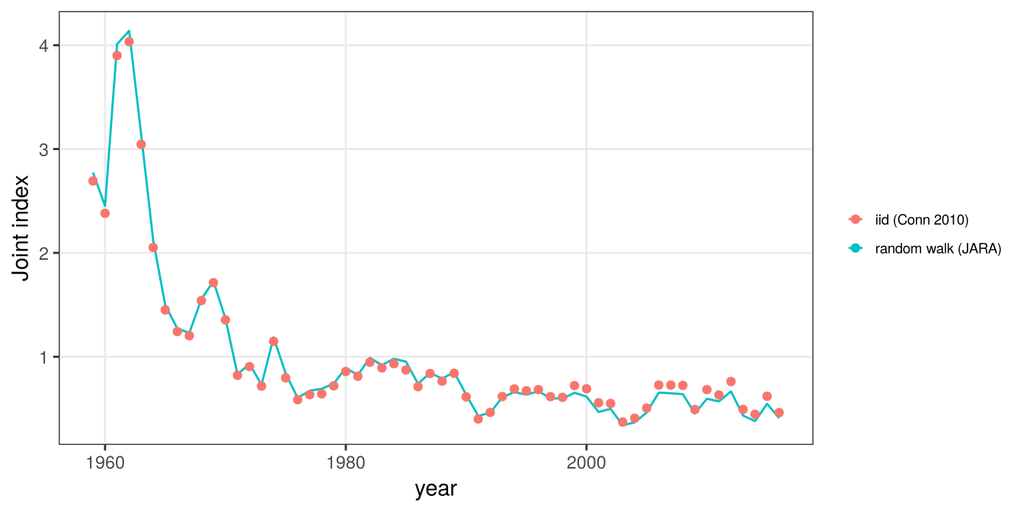

```r
ggplot2::ggplot(cmp, ggplot2::aes(year)) + ggplot2::geom_line(ggplot2::aes(y = rw, colour = "random walk (JARA)")) +
  ggplot2::geom_point(ggplot2::aes(y = iid, colour = "iid (Conn 2010)")) + ggplot2::labs(y = "Joint index", colour = NULL) +
  theme_jabba3()
```

For series that do not overlap in time, such as the two bigeye indices, only the random walk can scale them against each other.

Catch reconstruction, swept-area surveys from several areas and checks for conflicts between regions are covered in chapter *Other data features*.

# 6 Priors

All priors are in one list from `jb3_priors()`. Each prior is `c(median, log.sd, on)`: lognormal with the given median and log-scale SD, and an on/off switch (`on = 0` gives a flat prior on the log scale). The defaults follow JABBA (`build_jabba()`), except for the process error.

```r
pr <- jb3_priors(d, r = c(0.2, 0.5))
pr
```

```
#> JABBA3 priors (lognormal: median, log.sd; on = 1)
#>          median log.sd on
#> r      2.00e-01  0.500  1
#> K      1.08e+06  0.833  1
#> bkinit 9.00e-01  0.246  1
#> sdb    1.94e-01  0.300  1
#> m            NA  0.300  0
#> sdi    2.00e-01  0.500  0
#> sdb: FishLife centre 0.80 x sigR (0.50) x r^0.45
#> q: flat on log q
#> kdyn (dynamic sdb only): normal(0.31, 0.15)
```

| Prior | Default | Note |
| --- | --- | --- |
| `r` | `c(0.2, 0.5, 1)` | intrinsic growth rate; on by default |
| `K` | 8 x max catch, log.sd 0.833 (CV 1) | as JABBA; `c(NA, 0.833, 0)` for flat on log K |
| `bkinit` (alias `psi`) | `c(0.9, 0.246, 1)` | initial depletion $B_1/K$ |
| `sdb` | `"fishlife"` | process error SD at $B_{MSY}$, see below |
| `q` | flat on log q | matrix with one row `c(median, log.sd, on)` per catchability group |
| `m` | off | shape fixed from `BmsyK`; `c(median, log.sd, 1)` estimates it |
| `rho` | off (`c(0.7, 0.15, 0)`) | normal prior on the AR(1) coefficient, when estimated |
| `kdyn` | `max(0, 0.064 - 0.155 log r)`, sd 0.15 | depletion dependence of `sdb` (dynamic SD only) |
| `sdi` | off | index SD prior, used with `obs.error = "spict"` |
| `status` | `NULL` | data.frame(year, type, median, log.sd); type `"BK"`, `"BBmsy"` or `"FFmsy"` |

## 6.1 Process error: the FishLife prior

`sdb = "fishlife"` (default) replaces JABBA’s diffuse inverse-gamma prior on the process variance by a lognormal prior with a life-history centre,

$$\sigma_{MSY} \sim LN\left(\log(0.80\,\sigma_R\,r^{0.45}),\ 0.3\right),$$

with $r$ the median of the r prior and $\sigma_R$ the recruitment variability (`sigR = 0.5` when unknown). The relation comes from age-structured simulations of FishLife species (Thorson 2020) with selectivity at maturity (BioProcDyn). The inverse-gamma prior is still available (`sdb = "igamma"`) but its mode is at zero, so it is not recommended for posterior-mode fits; a fixed-scale prior is given as `sdb = c(median, log.sd, 1)`.

```r
jb3_priors(d, r = c(0.2, 0.5), sigR = 0.8)$sdb
```

```
#>    median    log.sd        on
#> 0.3102012 0.3000000 1.0000000
```

```r
jb3_priors(d, r = c(0.2, 0.5), sdb = c(0.1, 0.3, 1))$sdb
```

```
#> median log.sd     on
#>    0.1    0.3    1.0
```

## 6.2 r and the shape

The r prior refers to the JABBA parameterisation of the Pella-Tomlinson model, in which $F_{MSY} = r/m$ (section *Model equations*). An r prior derived for the Schaefer model ($m = 2$, $F_{MSY} = r/2$) therefore has to be converted when the shape changes: for the same $F_{MSY}$, the r for shape $m$ is $r_m = m\,F_{MSY}$. The JABBA package has the helper `JABBA::r_from_fmsy_bmsyk(Fmsy, BmsyK)`:

```r
if(requireNamespace("JABBA", quietly = TRUE))
  JABBA::r_from_fmsy_bmsyk(Fmsy = 0.1, BmsyK = c(0.5, 0.4, 0.37))
```

```
#>   Fmsy BmsyK        m         r
#> 1  0.1  0.50 2.000000 0.2000000
#> 2  0.1  0.40 1.188115 0.1188115
#> 3  0.1  0.37 1.011584 0.1011584
```

> A Schaefer r of 0.2 ($F_{MSY} = 0.1$) corresponds to r = 0.12 for $B_{MSY}/K = 0.4$ and r = 0.1 for the Fox model. Leaving the r prior unchanged while changing the shape changes the implied $F_{MSY}$.

## 6.3 Status priors

A prior on depletion, $B/B_{MSY}$ or $F/F_{MSY}$ in any year (e.g. from expert knowledge or a CMSY-type analysis) is added as a data frame:

```r
pr.st <- jb3_priors(d, r = c(0.2, 0.5),
                    status = data.frame(year = 2010, type = "BBmsy", median = 1, log.sd = 0.3))
pr.st$status
```

```
#>   year  type median log.sd
#> 1 2010 BBmsy      1    0.3
```

After fitting, `jbplot_bprior()` compares each status prior with the posterior of that quantity in that year, with the posterior-to-prior mean and variance ratios (PPMR, PPVR) as in JABBA:

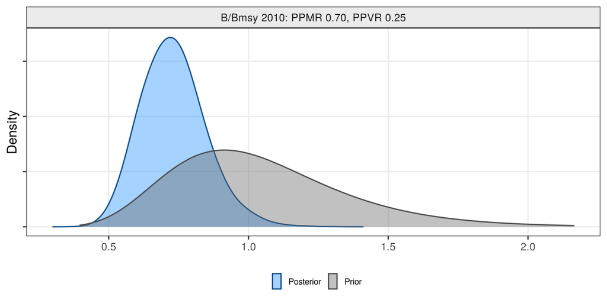

```r
fit.st <- jabba3(d, pr.st, jb3_model(shape = "fox"), osa = FALSE)
jbplot_bprior(fit.st)
```

## 6.4 Check 2: prior and posterior

After fitting, `jbplot_priorpost()` compares each prior with the posterior.

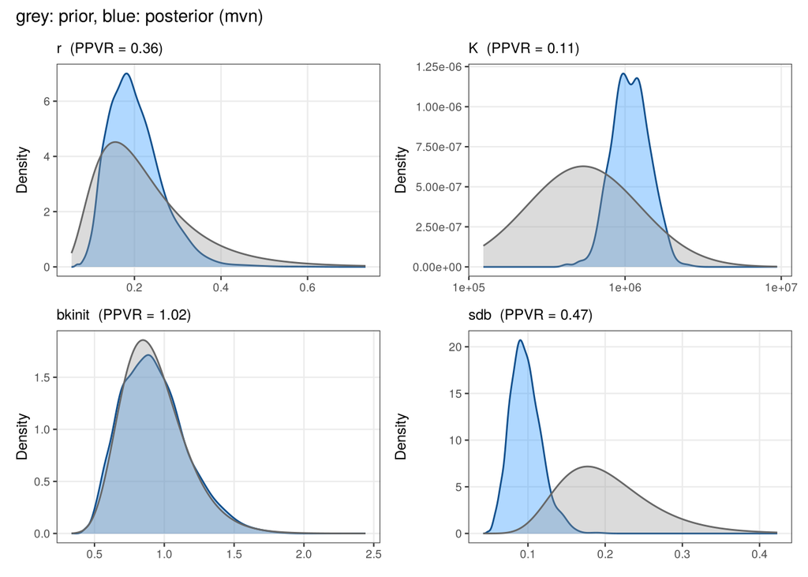

| What | Red flag | Action |
| --- | --- | --- |
| posterior equal to the prior | the data carry no information on that parameter | report it; sensitivity runs over the prior |
| posterior at the edge of the prior | prior-data conflict | revisit the prior; check the data and the model |

```r
jbplot_priorpost(fit)
```

# 7 Life history: r prior, generation time and Selex inputs

JABBA3 takes life-history information in the format of FLicc (length-based assessment with `fiticc()`): `lhpar`, an `FLPar` with growth, natural mortality, maturity at length and the weight-length relationship, and `selpar`, the selectivity parameters on the length scale (e.g. from `FLicc::selpars_flicc(fit)`). From these, the tools in this chapter give

- the maximum intrinsic rate of increase $r$ and the generation time GT from a Leslie matrix (`jb3_leslie()`);
- the r prior for the chosen production-function shape (`jb3_fmsy2r()`);
- guidance for the AR(1) persistence $\rho$ from GT (`jb3_rho_gt()`);
- the EB/SB curves for the Selex (spawning-biomass) model from length or age selectivity (`jb3_selex()`), with `jbplot_selex()`.

FLicc itself is not needed: its selectivity functions are included.

## 7.1 Leslie matrix: r and generation time

Life-history parameters of the FLicc alfonsino example (von Bertalanffy $L_\infty$ and $k$, natural mortality $M$, length at 50% maturity, weight at length $W = aL^b$; steepness `s`, default 0.7):

```r
FLPar <- FLCore::FLPar; FLPars <- FLCore::FLPars
lhpar <- FLPar(linf = 55.7, k = 0.08, M = 0.162, L50 = 31.1859,
               a = 0.004721956, b = 3.146168, s = 0.75)
jb3_leslie(lhpar)
```

```
#>          r         gt     lambda       spr0
#>   0.151033  17.963586   1.163035 632.546257
```

$r = \log\lambda$, with $\lambda$ the dominant eigenvalue of the Leslie matrix whose first row is the reproduction at the slope at the origin of the Beverton-Holt stock-recruitment relationship, $4h/(\phi_0(1-h))$ times weight and maturity at age; GT is the mean age of the spawners in the unfished population. Biology at age follows from von Bertalanffy growth (`t0`, default -0.5), $W = aL^b$ and logistic maturity at length ($L_{50}$, $L_{95}$; default $L_{50} + 0.2 L_\infty$), with ages up to where 1% of a cohort survives (`amax`). The calculation reproduces `JABBA::jbleslie()` and `FLSRTMB::productivity()`.

Sex-structured parameters go in a second dimension of the `FLPar` (or `list(F = , M = )`); reproduction is set by `sex` (default females):

```r
lh2 <- FLPar(array(c(55.7, 0.08, 0.162, 31.2, 0.0047, 3.15, 0.75,
                     50.0, 0.09, 0.180, 29.0, 0.0047, 3.15, 0.75), dim = c(7, 2, 1),
                   dimnames = list(params = c("linf", "k", "M", "L50", "a", "b", "s"),
                                   sex = c("F", "M"), iter = 1)))
lh2[, "F"]
```

```
#> An object of class "FLPar"
#>       sex
#> params F
#>   linf 55.7000
#>   k     0.0800
#>   M     0.1620
#>   L50  31.2000
#>   a     0.0047
#>   b     3.1500
#>   s     0.7500
#> units:  NA NA NA NA NA NA NA
```

```r
rbind(F = jb3_leslie(lh2, sex = "F"), M = jb3_leslie(lh2, sex = "M"))
```

```
#>           r       gt   lambda     spr0
#> F 0.1509523 17.97095 1.162941 638.2813
#> M 0.1645810 16.28603 1.178899 405.9126
```

`jb3_leslie()` also takes an `FLStock` (median `m`, `mat` and `stock.wt` at age, females from the `unit` dimension if present), `FLQuants` (`m`, `mat`, `wt`) by age with `unit = c("F", "M")`, or by length together with `lhpar` for growth:

```r
data(ple4, package = "FLCore")
jb3_leslie(ple4, h = 0.7)[c("r", "gt")]
```

```
#>         r        gt
#> 0.2377704 8.7073336
```

## 7.2 The r prior for the production-function shape

The Leslie $r$ is the per-capita growth at low biomass. In the Pella-Tomlinson form of JABBA3 this equals $r/(m-1)$, while $F_{MSY} = r/m$: using the Leslie $r$ directly is only consistent for the Schaefer model. Matching the prior on $F_{MSY}$ (from an age-structured equilibrium, or $r_{Leslie}/2$ as the Schaefer equivalent) keeps it consistent across shapes:

```r
r.les <- jb3_leslie(lhpar)[["r"]]
Fmsy  <- r.les/2                                   # Schaefer equivalent
c(schaefer = jb3_fmsy2r(Fmsy, shape = "schaefer"),
  pella0.4 = jb3_fmsy2r(Fmsy, BmsyK = 0.4),
  pella0.36 = jb3_fmsy2r(Fmsy, BmsyK = 0.36),
  fox = jb3_fmsy2r(Fmsy, shape = "fox"))
```

```
#>   schaefer   pella0.4  pella0.36        fox
#> 0.15103302 0.08972228 0.07233853 0.07559202
```

```r
jb3_r2fmsy(0.2, BmsyK = 0.4)                       # and back
```

```
#> [1] 0.1683339
```

## 7.3 Persistence from generation time

The generation time from the same Leslie matrix gives the guidance for the AR(1) coefficient (chapter *Model options*):

```r
gt <- jb3_leslie(lhpar)[["gt"]]
c(GT = gt, rho = jb3_rho_gt(gt))
```

```
#>       GT      rho
#> 17.96359  0.88000
```

## 7.4 Selex inputs from length selectivity

With the Selex model (`jb3_model(ebsb = )`) the state is spawning biomass and the indices and removals are mapped through the equilibrium ratio of exploitable to spawning biomass, EB/SB, as a function of SB/SB0. `jb3_selex()` computes this curve for each fleet from `lhpar` and length-based selectivity, over a grid of F with Beverton-Holt recruitment, and fits the saturating curve $c(u_1, u_2, u_3, P_1, P_2)$. Selectivity parameters use the FLicc names and functions (logistic: `SL50`, `SL95`; `dsnormal`: `mode`, `lsd`, `rsd`; `normal`; `binormal`; `bidsnormal`), here as an `FLPars` as returned by `FLicc::selpars_flicc(fit)`; selectivity at length is converted to age by integrating over the length-at-age distribution (`CVL = 0.1`).

```r
selpar <- FLPars(Gillnet = FLPar(mode = 32, lsd = 4, rsd = 15),
                 Longline = FLPar(SL50 = 28, SL95 = 36))
sx <- jb3_selex(lh2, selpar)
sx
```

```
#> JABBA3 Selex inputs: 2 selectivity curve(s); sexes F, M ; steepness 0.75
#>   Leslie r = 0.151, generation time = 18.0 years
#>             u1    u2    u3    P1 P2
#> Gillnet  1.402 0.949 2.250 0.005  1
#> Longline 1.290 1.094 3.585 0.006  1
#>   pass $ebsb to jb3_model(ebsb = )
```

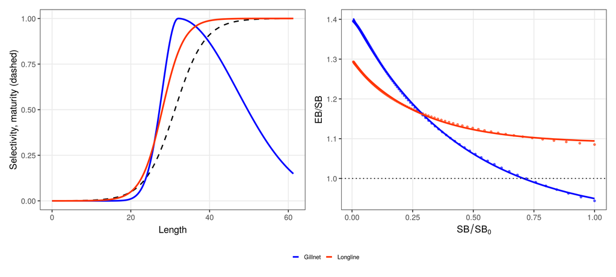

```r
jbplot_selex(sx)
```

The JABBA 5-parameter selectivity (JABBA-Select; `jb3_sel5()`: `SL50`, `SL95`, then a descending limb from `SLdesc` with coefficient of variation `CVdesc` towards a minimum `Smin`) can be used at length, alongside the FLicc functions:

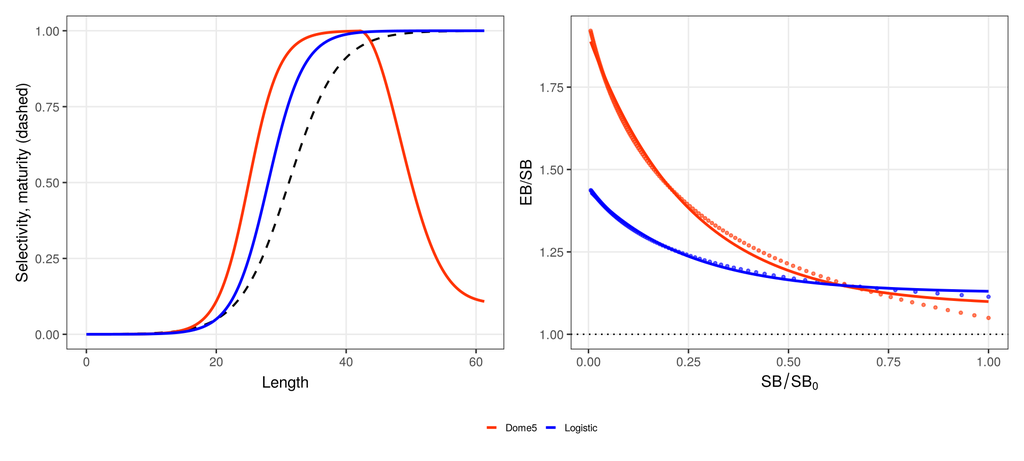

```r
sx5 <- jb3_selex(lhpar, list(Logistic = c(SL50 = 28, SL95 = 36),
                             Dome5 = c(SL50 = 25, SL95 = 32, SLdesc = 42, CVdesc = 0.15, Smin = 0.1)))
jbplot_selex(sx5)
```

or at age (`sel.type = "age"`; parameters in years):

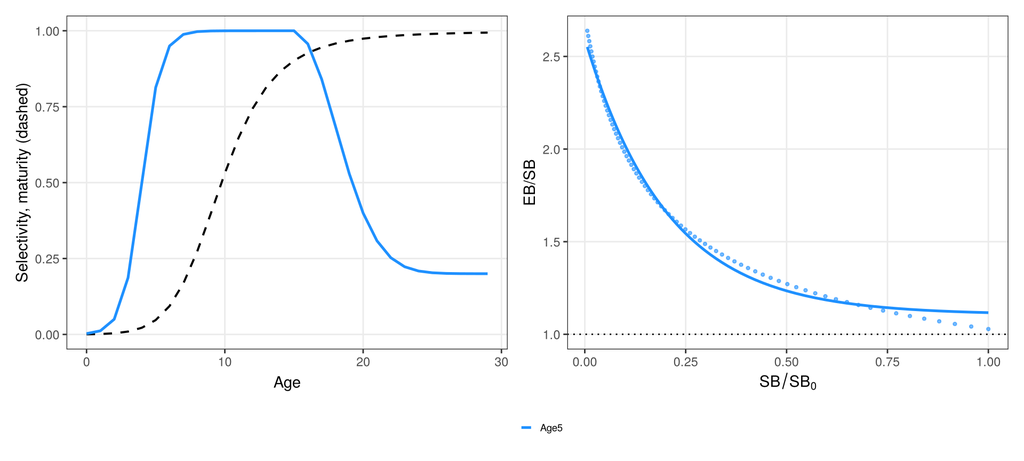

```r
sxa <- jb3_selex(lhpar, list(Age5 = c(SL50 = 4, SL95 = 6, SLdesc = 15, CVdesc = 0.2, Smin = 0.2)),
                 sel.type = "age")
jbplot_selex(sxa, at = "age")
```

## 7.5 A Selex fit

The output of `jb3_selex()` goes straight into `jb3_model(ebsb = )`; with several fleets, `ebsb.index` and `ebsb.catch` assign the curves to the indices and the removals. For bigeye tuna, with illustrative life-history and longline selectivity parameters:

```r
lh.bet <- FLPar(linf = 190, k = 0.2, M = 0.35, L50 = 105, a = 2.4e-5, b = 2.98, s = 0.8)
sx.bet <- jb3_selex(lh.bet, list(LL = c(SL50 = 80, SL95 = 110)))
c(jb3_leslie(lh.bet)[c("r", "gt")], rho = jb3_rho_gt(jb3_leslie(lh.bet)[["gt"]]))
```

```
#>         r        gt       rho
#> 0.3905233 7.5058989 0.7500000
```

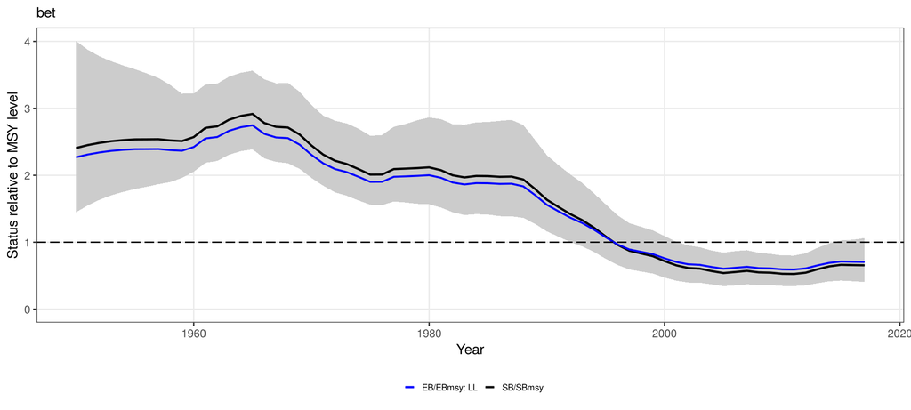

```r
fsx <- jabba3(d, pr, jb3_model(shape = "fox", ebsb = sx.bet), osa = FALSE)
jbplot_ebsb_status(fsx)
```

> Check that the selectivity is plausible against the length compositions (e.g. with an FLicc fit) before using the curve: it determines how the exploitable-biomass indices map onto the spawning-biomass state.

# 8 Model options

The model structure is set with `jb3_model()`, separately from the priors.

| Setting | Default | Role |
| --- | --- | --- |
| `shape` | `"pella"` | `"pella"` (shape from `BmsyK`), `"schaefer"` ($B_{MSY}/K = 0.5$) or `"fox"` ($m = 1.001$) |
| `BmsyK` | 0.4 | $B_{MSY}/K$ for the Pella-Tomlinson form |
| `lag` | 0 | production lag in years (age at maturity) |
| `rho` | 0 | AR(1) coefficient of the process deviations |
| `rw`, `rw.scale` | `FALSE`, 1 | random walk in the process deviations (the conditional $\rho = 1$ limit) |
| `sdb.form` | `"const"` | `"dyn"`: process error SD $\sigma_t = \sigma_{MSY}(B_t/B_{MSY})^{-k}$ |
| `sdb.fixed` | `NULL` | fix the process error SD (used by Tier 2) |
| `xlim` | `c(0.2, 3)` | bounds of $B/B_{MSY}$ in the dynamic SD |
| `biascor` | `FALSE` | lognormal bias correction of the process error |
| `start` | `"all"` | `"index"`: no process error before the first index year |
| `obs.error` | `"additive"` | `"additive"`: SD $= \sqrt{se^2 + sdi^2}$ (JABBA); `"spict"`: SD $= sdi \times w_t$ |
| `se.min`, `se.na` | `NULL`, 0.3 | minimum SE; SE where an index has SEs but a year has none |
| `sets.q`, `sets.var` | one per index | catchability and variance groups |
| `catch.error`, `sdc` | `TRUE`, 0.1 | catch with lognormal error |
| `ebsb`, `ebsb.index`, `ebsb.catch`, `ebsb.removal` | `NULL` | Selex: spawning biomass as the state, with EB/SB curves |
| `q.uniform` | `FALSE` | JABBA (JAGS) uniform prior on q |
| `P.bound`, `K.bound`, `sdi.bound` | JABBA | soft bounds |

## 8.1 Shape

```r
fits.shape <- lapply(c(schaefer = "schaefer", pella = "pella", fox = "fox"), function(s)
  jabba3(d, pr, jb3_model(shape = s), osa = FALSE))
t(sapply(fits.shape, function(f) c(Fmsy = f$refpts["Fmsy", "est"], MSY = f$refpts["MSY", "est"],
                                   BmsyK = f$refpts["BmsyK", "est"], B.Bmsy = tail(f$ts$est[f$ts$quantity == "B/Bmsy"], 1))))
```

```
#>               Fmsy      MSY     BmsyK    B.Bmsy
#> schaefer 0.1317475 88561.25 0.5000000 0.6544095
#> pella    0.1785929 84411.08 0.4000000 0.7521079
#> fox      0.1927352 83335.26 0.3680633 0.7972725
```

> With the same r prior the three shapes imply different $F_{MSY}$; convert the r prior with the shape (section *Priors*) when comparing shapes.

## 8.2 Process error: lag and persistence (recommended)

The BioProcDyn simulations showed that the standard assumption of independent process error with no lag makes surplus production models over-optimistic about rebuilding, and more so for late-maturing stocks. The true process deviations are persistent (lag-1 autocorrelation 0.7-0.8 for most life histories) and a model with independent deviations absorbs this persistence into r and K. The recommended configuration is (worked through on Atlantic blue marlin in chapter *The rebuilding protocol*)

- a **production lag** at the age at 50% maturity, `lag = amat`;
- **AR(1) process deviations** with $\rho = 0.75$ (sensitivity 0.5 and 0.9); $\sigma_{MSY}$ stays the marginal SD, $d_t \sim N(\rho d_{t-1}, \sigma^2(1-\rho^2))$;
- the FishLife prior on $\sigma_{MSY}$ (default).

```r
rec <- jabba3(d, pr, jb3_model(shape = "fox", lag = 3, rho = 0.75))
rec
```

```
#> JABBA3 fit: bet ( bet )  engine: rtmb
#>   model: fox + lag 3
#>   convergence: ok (max gradient 2.6e-12, Newton decrement 4.6e-25)
#>   estimates (mode, 95% CI):
#>             est      lci      uci
#> K      1.36e+06 6.62e+05 2.80e+06
#> r      1.89e-01 9.40e-02 3.78e-01
#> bkinit 9.04e-01 5.46e-01 1.50e+00
#> sdb    8.66e-02 5.43e-02 1.38e-01
#> q1     8.31e-07 3.18e-07 2.17e-06
#> q2     1.54e-06 5.84e-07 4.09e-06
#> sdi1   4.88e-02 1.65e-02 1.45e-01
#> sdi2   4.37e-02 1.66e-02 1.15e-01
#> m      1.00e+00       NA       NA
#> rho    7.50e-01       NA       NA
#> Bmsy   5.02e+05 2.44e+05 1.03e+06
#> Fmsy   1.88e-01 9.39e-02 3.78e-01
#> MSY    9.45e+04 6.52e+04 1.37e+05
#>   status 2017: B/Bmsy 0.78 (0.40-1.52), F/Fmsy 1.04 (0.46-2.34)
```

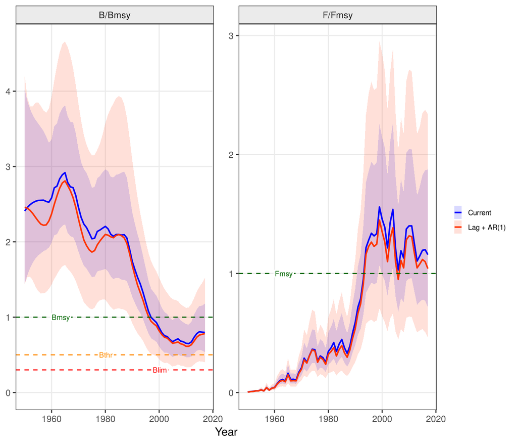

```r
jbplot_trj(list(Current = fit, `Lag + AR(1)` = rec), type = c("B/Bmsy", "F/Fmsy"))
```

### 8.2.1 Adjusting $\rho$ by generation time

$\rho = 0.75$ is the default. The persistence of process deviations increases with generation time (GT): across age-structured simulations for 486 bony-fish species of the FAO SOFIA list (FishLife life histories) the lag-1 autocorrelation followed $\rho \approx \exp(-2.2/GT)$ ($R^2 = 0.81$), and the default corresponds to GT of about 6-10 years. For shorter- or longer-lived stocks, adjust $\rho$ with the guidance table or `jb3_rho_gt()`; GT comes from the same Leslie matrix as the r prior (e.g. `JABBA::jbleslie()` or `FLSRTMB::productivity()`). Performance in simulation was flat between 0.5 and 0.9, so the adjustment matters mostly for short-lived species, where persistence is weak.

```r
knitr::kable(jb3_rho_table())
```

| Generation time (years) | Case-study stocks (GT) | Calibration median | Suggested rho |
| --- | --- | --- | --- |
| <= 3 | very short-lived species | 0.30 | 0.3-0.4 |
| 3-6 | Bay of Biscay sardine (3.2), northern shrimp (3.8) | 0.63 | 0.6 |
| 6-10 | Baltic herring (6.6), North Sea plaice (6.7), southern hake (8.4) | 0.78 | 0.75 (default) |
| > 10 | Icelandic cod (11.1), western horse mackerel (11.4), Biscay sea bass (11.9), North Sea anglerfish (12.6) | 0.80 | 0.8 |

```r
jb3_rho_gt(c(2, 4, 8, 15))
```

```
#> [1] 0.33 0.58 0.76 0.86
```

The scale prior on $\sigma_{MSY}$ stays tied to r (median $0.80\,\sigma_R\,r^{0.45}$, unbiased across the 486 species), so it follows the r prior directly in sensitivity runs on r.

$\rho$ can be estimated with a normal prior, by switching `priors$rho` on; with a single index this is less stable than fixing it.

```r
pr.rho <- jb3_priors(d, r = c(0.2, 0.5), rho = c(0.7, 0.15, 1))
fr <- jabba3(d, pr.rho, jb3_model(shape = "fox", lag = 3), osa = FALSE)
fr$report$rho
```

```
#> [1] 0.5659343
```

## 8.3 Depletion-dependent process error

`sdb.form = "dyn"` makes the process error SD increase at low biomass, $\sigma_t = \sigma_{MSY} x_t^{-k}$ with $x_t = B_t/B_{MSY}$ bounded to `xlim`, and k estimated with the life-history prior `kdyn`. In BioProcDyn modelling this inflation did not reduce the bias, so it is an option (and part of the Tier 2 workflow, section *Workflows*), not the default.

```r
fd <- jabba3(d, pr, jb3_model(shape = "fox", lag = 3, sdb.form = "dyn"), osa = FALSE)
fd$pars[c("sdb", "kdyn"), c("est", "lci", "uci")]
```

```
#>             est        lci       uci
#> sdb  0.09643272 0.06359386 0.1462290
#> kdyn 0.37500131 0.10199173 0.6480109
```

## 8.4 Index observation error

`obs.error = "additive"` (default, as JABBA) adds an estimated SD `sdi` to the input standard errors, $SD_t = \sqrt{se_t^2 + sdi^2}$. `obs.error = "spict"` uses SPiCT’s form, $SD_t = sdi \times w_t$, where the input SEs enter only as relative weights $w_t$ (as `stdevfacI`); a prior on `sdi` is then available through `priors$sdi` (here on, as without it the SD of the second bigeye index collapses towards zero). Indices can share catchability (`sets.q`) or variance (`sets.var`), e.g. `sets.q = c(1, 1)` for two segments of one fleet.

```r
pr.sdi <- jb3_priors(d, r = c(0.2, 0.5), sdi = c(0.1, 0.5, 1))
fsp <- jabba3(d, pr.sdi, jb3_model(shape = "fox", obs.error = "spict"), osa = FALSE)
fsp$pars[grep("sdi", rownames(fsp$pars)), c("est", "lci", "uci")]
```

```
#>             est        lci        uci
#> sdi1 0.07384509 0.04056742 0.13442058
#> sdi2 0.05337111 0.02912100 0.09781518
```

## 8.5 Catch error

With `catch.error = TRUE` (default) the catch is estimated with lognormal error (SD `sdc = 0.1`) as random effects, as JABBA’s `add.catch.CV = TRUE`; this absorbs small inconsistencies between catch and production. `catch.error = FALSE` treats the catch as known.

## 8.6 Selex (spawning biomass as the state)

With `ebsb` the state is spawning biomass and the indices and removals are mapped to it through the equilibrium ratio of exploitable to spawning biomass, a function of depletion given as a curve `c(u1, u2, u3, P1, P2)` (or a named list of curves, one per selectivity), assigned to indices with `ebsb.index` and to the removals with `ebsb.catch`. The priors are then on the spawning-biomass scale. The curves come from an age-structured equilibrium analysis (e.g. FLBRP) or from a JABBA Selex setup via `jbinput2jabba3()`. Selex is a special case for stocks where the fishery selects well below maturity and is not covered further here.

`jbplot_ebsb_status()` shows the spawning biomass status (the state) with the exploitable biomass status implied by each curve, EB/EB<sub>MSY</sub> = (SB/SB<sub>MSY</sub>) $\times$ $\rho$(SB/K)/$\rho$(SB<sub>MSY</sub>/K). With an illustrative curve:

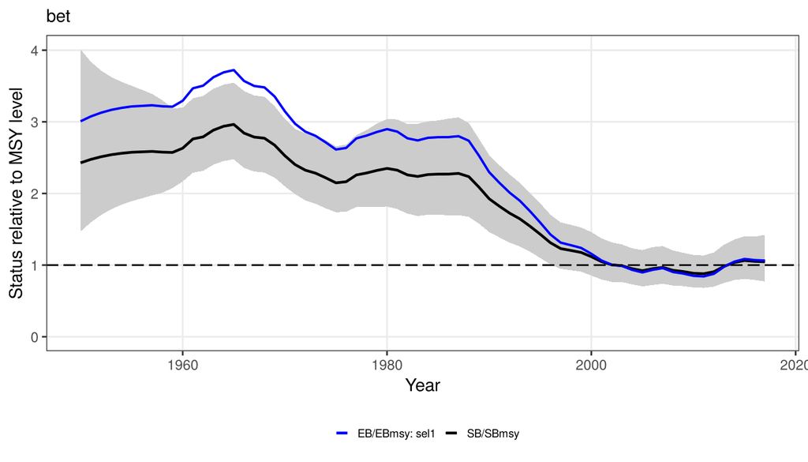

```r
fsel <- jabba3(d, pr, jb3_model(shape = "fox", ebsb = c(0.6, 1.2, 3, 0.1, 1)), osa = FALSE)
jbplot_ebsb_status(fsel)
```

# 9 Fitting

`jabba3()` fits the model.

| Argument | Default | Role |
| --- | --- | --- |
| `engine` | `"rtmb"` | `"rtmb"`: posterior mode, states Laplace-integrated; `"nuts"`: full posterior with tmbstan |
| `ndraws` | 0 | draws from the MVN approximation at the mode (Kobe plot, projections) |
| `nuts` | `list()` | tmbstan settings: `chains`, `iter`, `warmup`, `seed`, `cores`, `thin`, `control` |
| `osa` | `TRUE` | one-step-ahead residuals by particle filter |
| `se` | `TRUE` | standard errors by the delta method; `FALSE` for fast point estimates |
| `workflow`, `amat` | `"none"` | BioProcDyn workflows (section *Workflows*) |
| `run` | `NULL` | run name for plots |
| `peels`, `index.peels` | 0 | remove the last years of all data or of the indices (used by retro and hindcast) |
| `nstart` | 4 | guarded restarts |

## 9.1 Posterior mode

The default: the log-depletion states (and catch deviations) are integrated by the Laplace approximation, and the fixed effects (log K, log r, log q, initial depletion, process and observation SDs) are estimated at the mode of the posterior. Intervals come from the delta method on the log scale.

```r
fit$time
```

```
#> [1] 2.547
```

```r
fit$pars[, c("est", "lci", "uci")]
```

```
#>                 est          lci          uci
#> K      1.174749e+06 6.887375e+05 2.003718e+06
#> r      1.929279e-01 1.067678e-01 3.486183e-01
#> bkinit 8.886059e-01 5.504944e-01 1.434384e+00
#> sdb    9.452480e-02 6.313738e-02 1.415158e-01
#> q1     9.070171e-07 4.868664e-07 1.689745e-06
#> q2     1.705595e-06 9.195735e-07 3.163483e-06
#> sdi1   5.010975e-02 1.645224e-02 1.526229e-01
#> sdi2   4.403320e-02 1.664934e-02 1.164565e-01
#> m      1.001000e+00           NA           NA
```

```r
fit$refpts[, c("est", "lci", "uci")]
```

```
#>                est          lci          uci
#> Bmsy  4.323821e+05 2.534990e+05 7.374952e+05
#> Fmsy  1.927352e-01 1.066611e-01 3.482700e-01
#> MSY   8.333526e+04 7.008997e+04 9.908358e+04
#> K     1.174749e+06 6.887375e+05 2.003718e+06
#> BmsyK 3.680633e-01           NA           NA
```

```r
head(fit$ts[fit$ts$quantity == "B/Bmsy", ], 3)
```

```
#>     year quantity      est      lci      uci    se.log  run
#> 137 1950   B/Bmsy 2.409312 1.443252 4.022017 0.2614502 <NA>
#> 138 1951   B/Bmsy 2.457059 1.560153 3.869581 0.2317252 <NA>
#> 139 1952   B/Bmsy 2.493103 1.652886 3.760432 0.2096967 <NA>
```

The time series in `fit$ts` hold B, F, B/Bmsy, F/Fmsy, B/K, catch and the process deviations with 95% intervals.

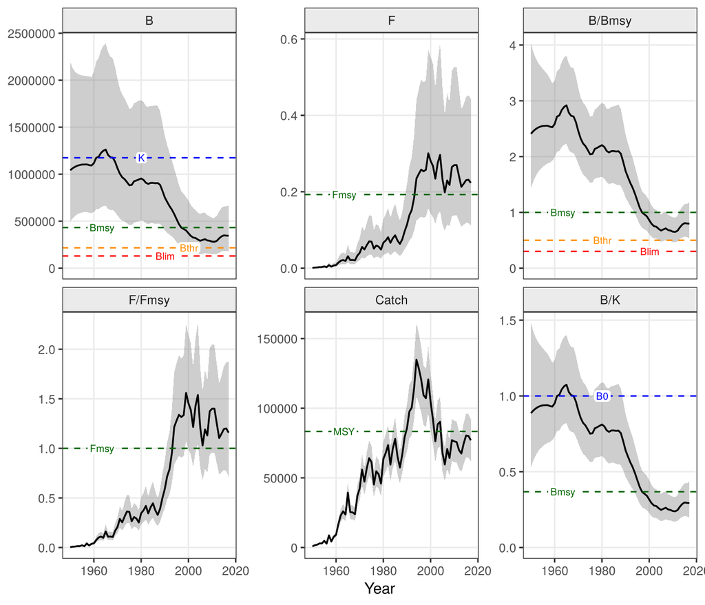

```r
jbplot_trj(fit)
```

`jbplot_trj()` and `jbplot_advice()` share the JAGG options: `nested = TRUE` for 90/60% bands (the default in `jbplot_advice()`), `extra` for further reference points (e.g. $B_{pa}$; an `extra` $B_{lim}$ or $B_{thr}$ replaces the default), `drop.last` to drop the last year of F and catch, `proj` to append projections and `probs` for other bands. $B_{thr} = 0.5 B_{MSY}$ and $B_{lim} = 0.3 B_{MSY}$ (SPiCT benchmark defaults) are drawn by default (`bthr`, `blim`; `NULL` to omit). A list of fits is coloured by run.

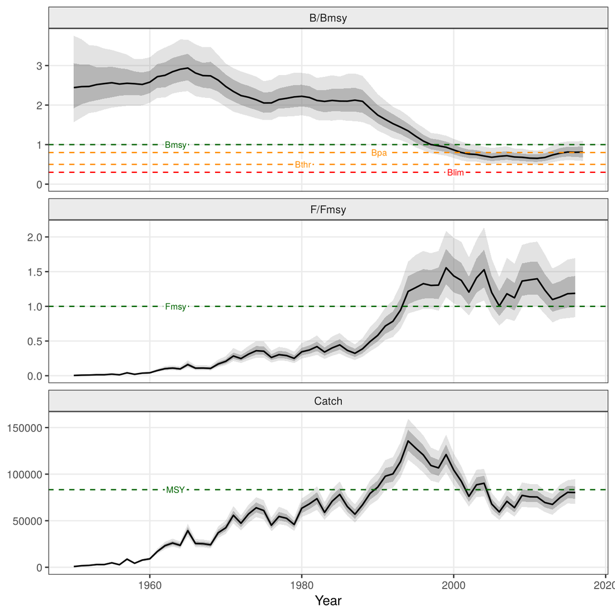

```r
jbplot_advice(fit, extra = c(Bpa = 0.8), drop.last = TRUE)
```

`jbplot_kobe(fit, year = )` shows the uncertainty in any year (gold diamond), and `jbplot_biplot()` is the ‘post-modern’ biplot of Quinn and Collie (2005), as JABBA’s: $B/B_{MSY}$ against $F/F_{MSY}$ with the zones of a hockey-stick harvest control rule (target 0.8 $F_{MSY}$, threshold 0.2 $B_{MSY}$) and the 50/80/95% density contours of the terminal status.

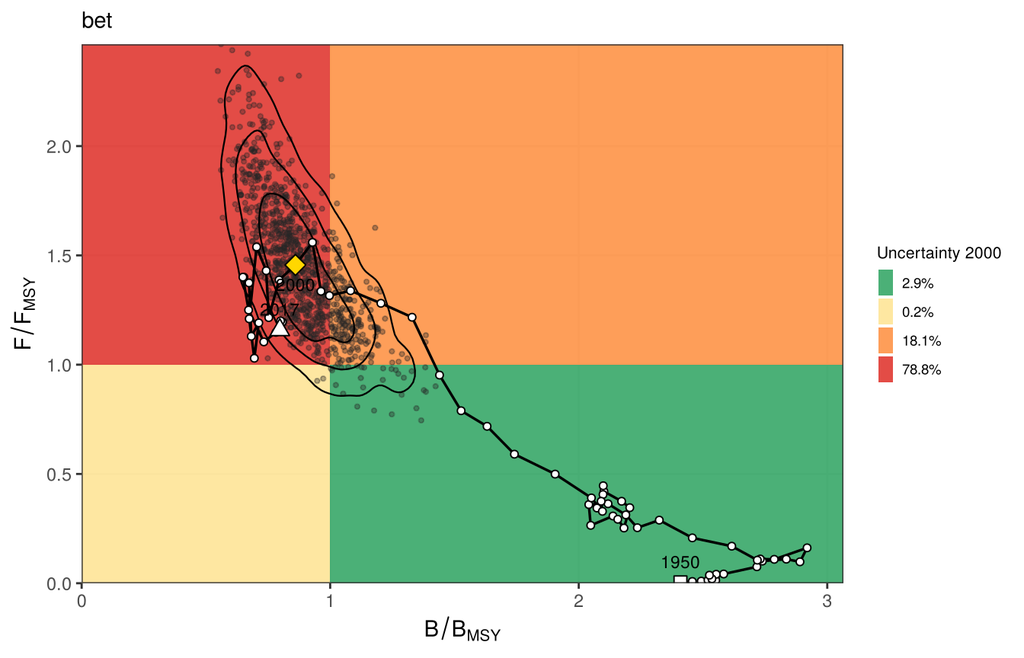

```r
jbplot_kobe(fit, year = 2000)
```

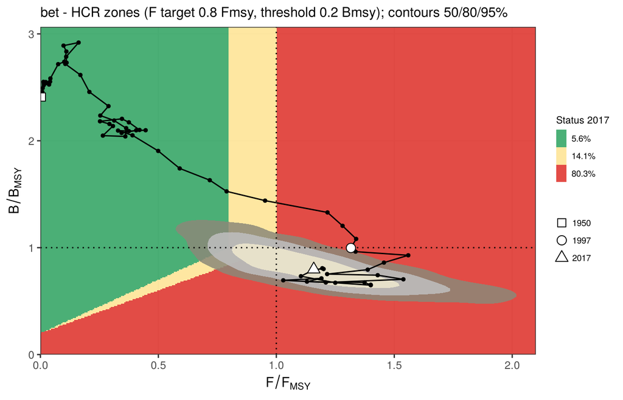

```r
jbplot_biplot(fit)
```

## 9.2 Catch

With catch error (the default) the estimated catch can depart a little from the observed catch. `jbplot_catch()` shows both, and `jbplot_catcherror()` adds the log ratio of estimated to observed catch (as JABBA’s `jbplot_catcherror()`).

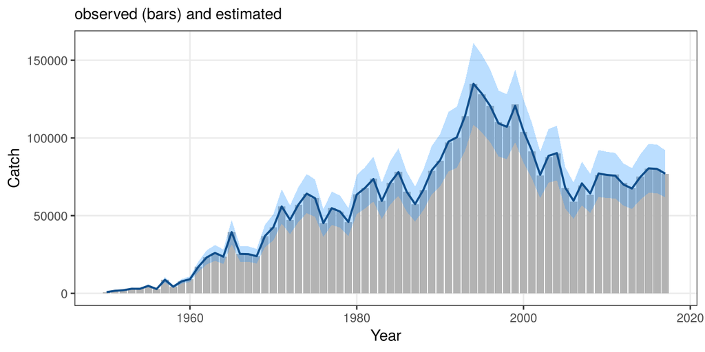

```r
jbplot_catch(fit)
```

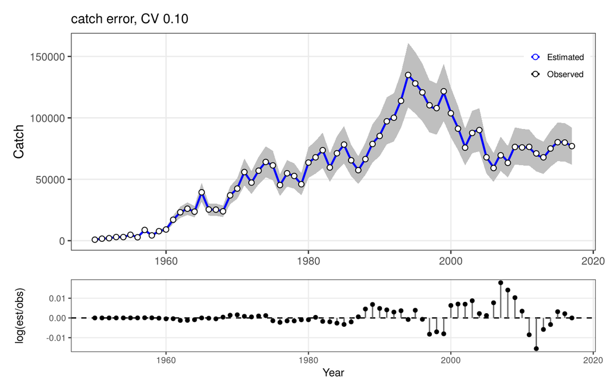

```r
jbplot_catcherror(fit)
```

## 9.3 Fast point estimates

For simulation testing, MSE and large grids, `se = FALSE, osa = FALSE` skips the standard errors and residuals:

```r
system.time(fq <- jabba3(d, pr, jb3_model(shape = "fox"), se = FALSE, osa = FALSE))
```

```
#>    user  system elapsed
#>   0.127   0.000   0.127
```

```r
fq$pars[c("K", "r"), "est"]
```

```
#> [1] 1.174749e+06 1.929279e-01
```

## 9.4 Full posterior with NUTS

`engine = "nuts"` samples all parameters and states of the same model with tmbstan (no Laplace approximation), started from the mode. Posterior medians and quantiles replace the mode summaries in `pars`, `refpts` and `ts`.

NUTS is meant for final runs, so the defaults are rigorous: 3 chains of 4000 iterations (half warmup). After sampling, `jabba3()` checks convergence and warns if the rank-normalised $\hat{R}$ exceeds 1.01, the bulk or tail effective sample size is below 100 per chain, there are divergent transitions, or E-BFMI is below 0.3; the full table is in `fn$nuts$diags` (see *NUTS diagnostics*). For bigeye the default run takes about half a minute.

```r
fn <- jabba3(d, pr, jb3_model(shape = "fox"), engine = "nuts", nuts = list(cores = 3))
fn
```

```
#> JABBA3 fit: bet ( bet )  engine: nuts  + 6000 nuts draws
#>   model: fox
#>   convergence: ok (max gradient 4.4e-12, Newton decrement 3.0e-25); NUTS Rhat max 1.008, ESS min 278, divergent 0
#>   estimates (posterior median, 95% CrI):
#>             est      lci      uci
#> K      1.38e+06 8.28e+05 2.67e+06
#> r      1.64e-01 7.99e-02 2.85e-01
#> bkinit 8.71e-01 5.53e-01 1.28e+00
#> sdb    1.01e-01 6.71e-02 1.45e-01
#> q1     9.07e-07 4.87e-07 1.69e-06
#> q2     1.71e-06 9.20e-07 3.16e-06
#> sdi1   5.01e-02 1.65e-02 1.53e-01
#> sdi2   4.40e-02 1.66e-02 1.16e-01
#> m      1.00e+00 1.00e+00 1.00e+00
#> Bmsy   5.07e+05 3.05e+05 9.82e+05
#> Fmsy   1.64e-01 7.98e-02 2.85e-01
#> MSY    8.33e+04 6.40e+04 1.05e+05
#>   status 2017: B/Bmsy 0.81 (0.52-1.19), F/Fmsy 1.16 (0.68-1.98)
```

## 9.5 Fit to the indices

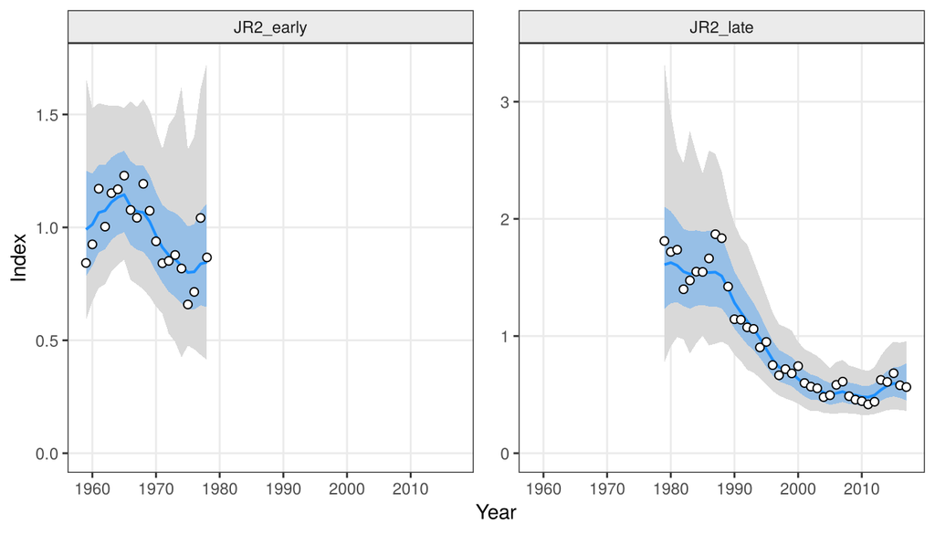

```r
jbplot_fits(fit)
```

`jbplot_fits(fit, log = TRUE)` plots on the log scale; the shaded band is the posterior predictive interval including observation error.